# Preparação de dados

Aplicações com o pacote geomarkbr

Autor

Gustavo Givisiez

Data de Publicação

6 de maio de 2026

**Código**

```r
library(dplyr)
library(sf)
library(tmap)
library(geomarkbr)
tmap::tmap_mode("plot")
```

# 1 OpenStreetMap

**Nota😳 Código de desenvolvimento (dev)**

**Código**

```r
# dev: ler os setores censitários e salvar como rds
setores_rj <- gm_read_sectors_data(code = 33)|>
  dplyr::mutate(code_tract = as.character(code_tract))

dados_pf = "site/tutorials/dados/"

readr::write_sf(setores_rj,
                paste0(dadps_pf,"shape_rj.gpkg"),
                overwrite = TRUE)
```

**Código**

```r
limites_sjb = geobr::read_municipality(2022, code_muni = 3305000)
sf::write_sf(limites_sjb,
                paste0(dados_pf,"limites_sjb.gpkg"),
                overwrite = TRUE)

bbox <- sf::st_bbox(limites_sjb)
```

**Código**

```r
# dev: baixar pontos de interesse do OSM

endpoints <- c(
  "https://overpass-api.de/api/interpreter",
  "https://overpass.kumi.systems/api/interpreter",
  "https://api.openstreetmap.fr/oapi/interpreter",
  "https://overpass.osm.vi-di.fr/api/interpreter"
)

osm_pois <- NULL

for (ep in endpoints) {
  message("Tentando endpoint: ", ep)

  ok <- tryCatch(
    {
      osmdata::set_overpass_url(ep)
      TRUE
    },
    error = function(e) {
      message("Falhou ao definir endpoint: ", conditionMessage(e))
      FALSE
    }
  )

  if (!ok) next

  osm_pois <- tryCatch(
    {
      osmdata::opq(
        bbox = bbox,
        timeout = 300
      ) |>
        osmdata::add_osm_feature(key = "amenity") |>
        osmdata::osmdata_sf()
    },
    error = function(e) {
      message("Falhou na consulta: ", conditionMessage(e))
      NULL
    }
  )

  if (!is.null(osm_pois)) break
}

readr::write_rds(
  osm_pois, "site/tutorials/dados/osm_pois.rds")

pois_points <- osm_pois$osm_points
pois_polygons <- osm_pois$osm_polygons

sf::write_sf(
  pois_points,
  "inst/extdata/osm_pois_sjb_points.gpkg",
  delete_dsn = TRUE
)

sf::write_sf(
  pois_polygons,
  "inst/extdata/osm_pois_sjb_polygons.gpkg",
  delete_dsn = TRUE

)
```

## 1.1 Por que usar OpenStreetMap?

O OpenStreetMap (OpenStreetMap Foundation, 2023) é uma base de dados geográficos colaborativa e aberta, construída por voluntários ao redor do mundo. Seu funcionamento é frequentemente comparado ao da Wikipédia (Wikipedia, 2023): qualquer pessoa pode editar, corrigir ou adicionar informações espaciais. Isso faz com que o OSM seja constantemente atualizado e particularmente útil em aplicações urbanas e regionais.

Os dados do OSM incluem uma enorme variedade de elementos espaciais, como vias, ciclovias, escolas, hospitais, farmácias, pontos de ônibus, comércios, áreas verdes e equipamentos urbanos em geral. Essas informações podem complementar os dados do Censo Demográfico, permitindo análises mais detalhadas da infraestrutura urbana, da acessibilidade e da distribuição espacial de serviços.

Uma das grandes vantagens do OSM é sua flexibilidade. Diferentemente de muitas bases oficiais, os dados podem ser baixados diretamente no R e filtrados por categorias específicas, chamadas de *tags*. Isso permite, por exemplo, mapear apenas escolas, supermercados ou vias arteriais de uma cidade.

Entretanto, os dados do OSM também possuem limitações importantes. Como o mapeamento é colaborativo, a cobertura e a qualidade das informações variam bastante conforme o local. Áreas centrais e cidades maiores tendem a possuir dados mais completos, enquanto municípios pequenos ou regiões periféricas podem apresentar lacunas, inconsistências ou classificações diferentes para elementos semelhantes. Por isso, os dados do OSM devem sempre ser analisados de forma crítica e, quando possível, comparados com outras fontes de informação.

## 1.2 Baixar dados do OpenStreetMap

Para consultar dados do OpenStreetMap, precisamos primeiro definir uma área de interesse. Nesta aula, essa área será construída a partir dos setores censitários de São João da Barra. A ideia é usar a própria geometria do município como referência espacial para buscar, no OSM, elementos que estejam dentro ou próximos dessa área.

O pacote `osmdata` trabalha frequentemente com uma **bounding box**, isto é, um retângulo que envolve a área de interesse. Esse retângulo é definido pelos limites mínimo e máximo de longitude e latitude. Embora a área real do município tenha forma irregular, a bounding box fornece uma forma simples e eficiente de delimitar a consulta inicial ao OSM.

**Código**

```r
dados_pf = here::here('tutorials/dados/') # render
setores <- gm_read_sectors_shape(
  path = paste0(dados_pf,"limites_sjb.gpkg"),
  code = 3305000
)

# Garantir que a base está em latitude/longitude (WGS84)
setores_ll <- sf::st_transform(setores, 4326)

# Criar a bounding box da área de estudo
bbox <- sf::st_bbox(setores_ll)

bbox
```

```
#>      xmin      ymin      xmax      ymax
#> -41.19432 -21.91194 -40.98183 -21.61775
```

Com a bounding box definida, podemos montar uma consulta ao OpenStreetMap. A consulta é formada por duas partes principais: a área de busca e a tag que queremos recuperar. No exemplo abaixo, vamos buscar pontos de interesse classificados como `amenity`, uma chave bastante usada no OSM para representar equipamentos e serviços, como escolas, hospitais, farmácias, restaurantes e bancos.

**Código**

```r
osm_pois <- osmdata::opq(
  bbox = bbox,
  timeout = 180
) |>
  osmdata::add_osm_feature(
    key = "amenity"
  ) |>
  osmdata::osmdata_sf()

pois_points <- osm_pois$osm_points
pois_polygons <- osm_pois$osm_polygons
```

Esse comando, muito frequentemente, retorna erros *HTTP 504 Gateway Timeout* ou *HTTP 429 Too Many Requests*. Isso ainda é mais frequente em ambiente de laboratórios de ensino. Outras vezes o erro é do servidor mesmo: o servidor padrão às vezes fica lento ou indisponível. O osmdata prevê formas alteranativas de alternar o endpoint (URL) para acessar os dados do OSM, e o `opq()` permite controlar timeout, tipos de objeto e parâmetros da consulta. Consulte o bloco de **Código de desenvolvimento** no início deste documento ou a ajuda com `?opq`.

Para contornar esse problema, as bases do OSM para São João da Barra foram salvas no diretório de exemplos do `geomarkbr`.

**Código**

```r
osm_pois_points_path <- gm_example_data_path("osm_pois_sjb_points.gpkg")
osm_pois_polygons_path <- gm_example_data_path("osm_pois_sjb_polygons.gpkg")

osm_pois_points <- sf::read_sf(osm_pois_points_path)
osm_pois_polygons <- sf::read_sf(osm_pois_polygons_path)
```

**Código**

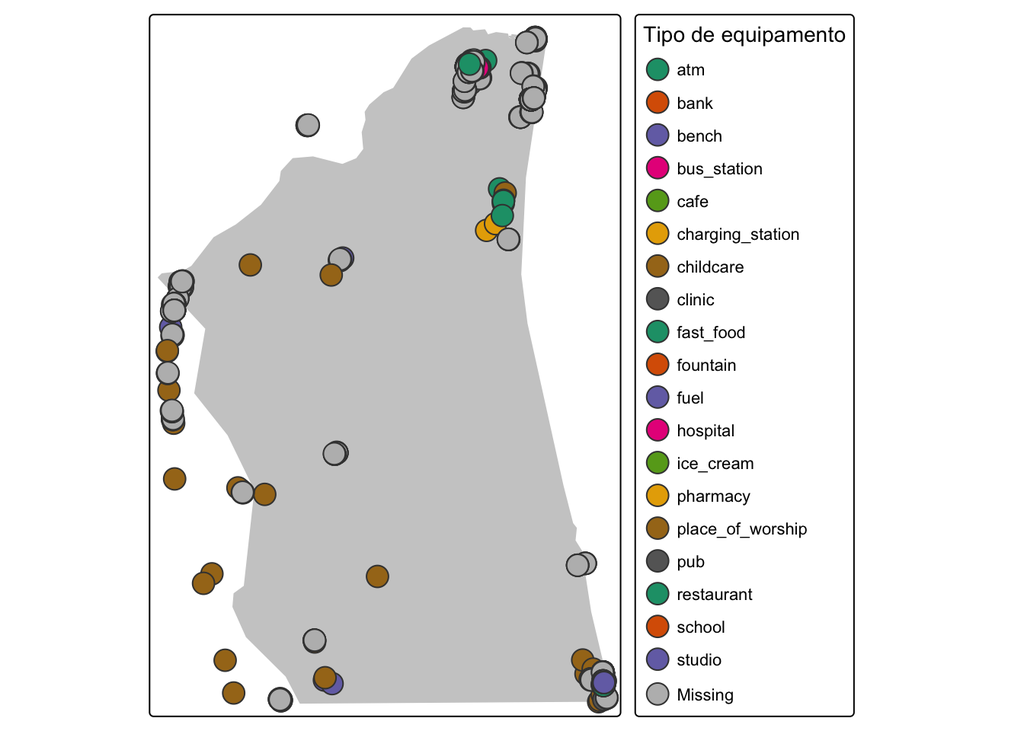

```r
limites_sjb = sf::read_sf(paste0(dados_pf,"limites_sjb.gpkg"))
limites_sjb_ll <- sf::st_transform(limites_sjb, 4326) #EPSG:4326 é WGS84 que é usado pelo OSM

base_tm = tm_shape(limites_sjb_ll)+
  tm_polygons(fill = 'grey80', col = 'grey80')

pontos_tm =
  tm_shape(osm_pois_points) +
  tm_symbols(
    fill = "amenity",
    fill.scale = tm_scale_categorical(
      values = "brewer.dark2"),
    fill.legend = tm_legend(
      title = "Tipo de equipamento"
    ))

base_tm + pontos_tm
```

Mas, percebam que há alguns problemas: alguns pontos estão fora dos limites do município e há muitos pontos com `osm_pois_points = missing`. Dessa forma é melhor filtrar o banco para tirar esses missings e fazer um *interseção* para melhorar.

**Código**

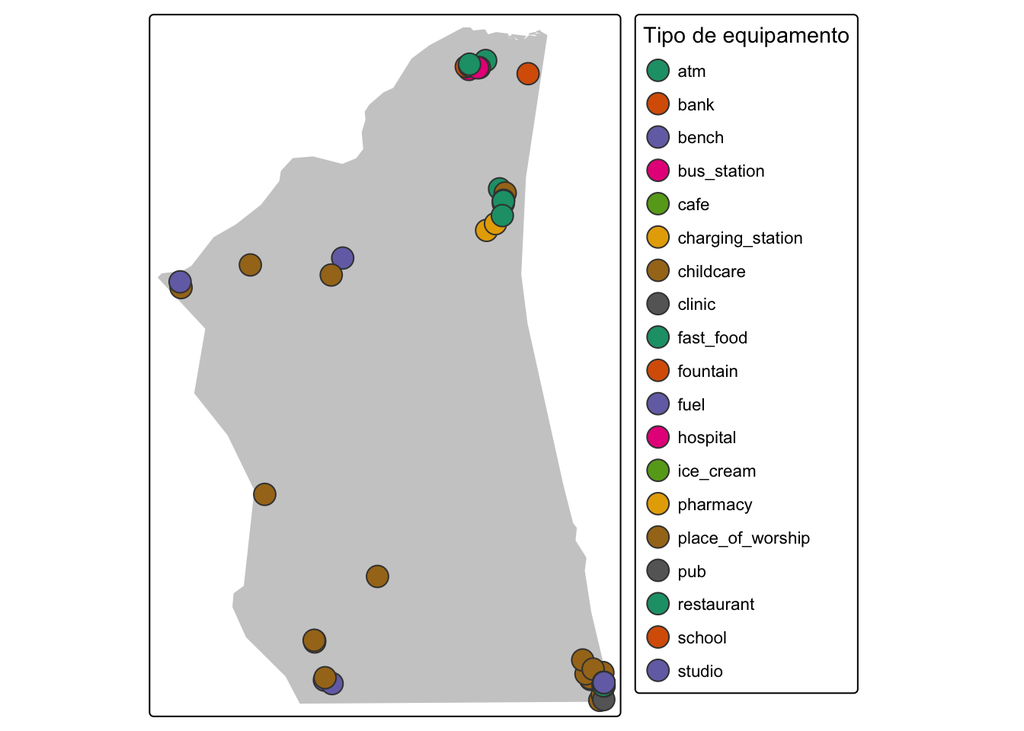

```r
osm_pois_points_clean = osm_pois_points %>%
  filter(!is.na(amenity)) %>%
  st_intersection(limites_sjb_ll)

pontos_tm =
  tm_shape(osm_pois_points_clean) +
  tm_symbols(
    fill = "amenity",
    fill.scale = tm_scale_categorical(
      values = "brewer.dark2"),
    fill.legend = tm_legend(
      title = "Tipo de equipamento"
    ))

base_tm + pontos_tm
```

## 1.3 Entendendo as tags

O OpenStreetMap organiza as informações geográficas por meio de um sistema de *tags*, estruturado em pares do tipo `key = value`. Cada objeto do mapa, seja uma rua, uma escola, uma farmácia ou um supermercado, pode receber uma ou várias tags descrevendo suas características. Nesse sistema, a `key` representa o tipo geral do atributo, enquanto o `value` especifica a categoria associada àquele atributo.

Por exemplo, a tag: `amenity = school` indica que o objeto representa um equipamento urbano (*amenity*) classificado como escola (*school*). Da mesma forma, a tag `shop = supermarket` identifica um estabelecimento comercial (*shop*) do tipo supermercado (*supermarket*). Já `highway = primary` representa uma via (*highway*) classificada como arterial principal (*primary*). O OSM utiliza um sistema relativamente flexível de classificação. Isso significa que diferentes usuários podem mapear elementos semelhantes utilizando tags diferentes ou níveis distintos de detalhamento. Apesar disso, existe uma extensa documentação comunitária na Wiki do OpenStreetMap, que funciona como referência para as principais categorias e convenções utilizadas no mapeamento.

As páginas mais importantes para explorar essas classificações são:

- [Map Features](https://wiki.openstreetmap.org/wiki/Map_features): visão geral das principais categorias do OSM;
- Key:amenity: equipamentos e serviços urbanos;
- Key:highway: classificação de vias;
- [Map Features: amenity](https://wiki.openstreetmap.org/wiki/Template:Map_Features:amenity): lista detalhada de equipamentos urbanos.

Sendo assim, é possível filtar para exibirmos apenas o que nos interessa:

**Código**

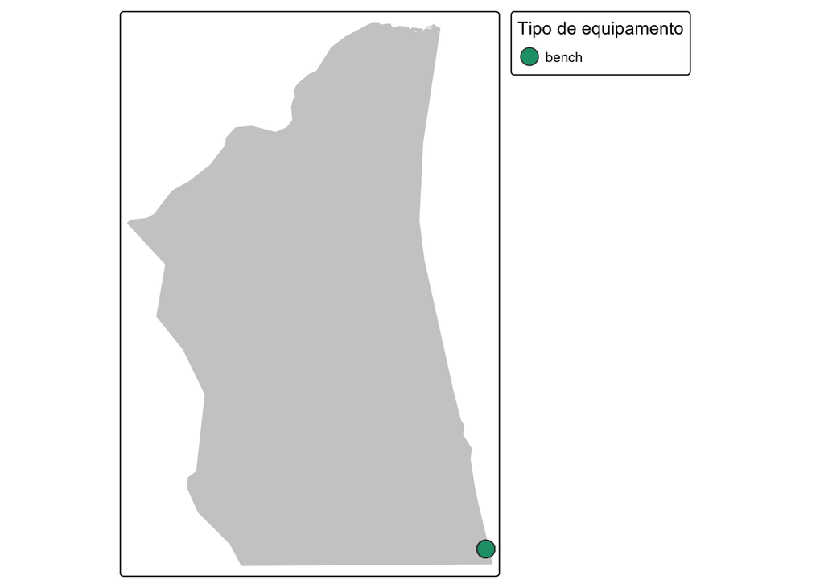

```r
osm_pois_points_selected = osm_pois_points_clean %>%
  filter(amenity == 'bench')

pontos_tm =
  tm_shape(osm_pois_points_selected) +
  tm_symbols(
    fill = "amenity",
    fill.scale = tm_scale_categorical(
      values = "brewer.dark2"),
    fill.legend = tm_legend(
      title = "Tipo de equipamento"
    ))

base_tm + pontos_tm
```

O próximo passo seria selecionar colunas úteis, como `osm_id`, `name`, `amenity`, `geometry` e outros pontos que nos interessam. Mas, investigando a base de dados mais a fundo, notamos que base de POIs para São João está bem incompleta por enquanto.

**Código**

```r
freq_amenity <- as.data.frame(
  sort(
    table(osm_pois_points_clean$amenity),
    decreasing = TRUE
  )) %>%
  mutate(Rel = 100*Freq/sum(Freq))


names(freq_amenity) <- c("tipo", "frequencia","relativa")

freq_amenity
```

```
#>                tipo frequencia  relativa
#> 1  place_of_worship         16 28.070175
#> 2             bench          8 14.035088
#> 3        restaurant          8 14.035088
#> 4              fuel          4  7.017544
#> 5              bank          3  5.263158
#> 6       bus_station          2  3.508772
#> 7  charging_station          2  3.508772
#> 8            clinic          2  3.508772
#> 9            school          2  3.508772
#> 10              atm          1  1.754386
#> 11             cafe          1  1.754386
#> 12        childcare          1  1.754386
#> 13        fast_food          1  1.754386
#> 14         fountain          1  1.754386
#> 15         hospital          1  1.754386
#> 16        ice_cream          1  1.754386
#> 17         pharmacy          1  1.754386
#> 18              pub          1  1.754386
#> 19           studio          1  1.754386
```

Nesse sentido, uma base com os supermercados de Grussaí foi montada no Google Earth e exportada para o formato `*.kml`

[figure not shown]

Exemplo de pontos coletados no Google Earth

## 1.4 Renomear

- Padronizar nomes para o padrão do pacote
- Exemplo:
  - `name` → `nome`
  - `amenity` → `tipo_equipamento`

## 1.5 Calcular / classificar

- Criar variáveis derivadas:
  - tipo geral do ponto
  - presença/ausência de nome
  - categoria agregada
- Exemplo:
  - educação
  - saúde
  - comércio alimentar

## 1.6 Unir / relacionar com a base censitária

Aqui o “unir” muda um pouco em relação ao IBGE.

No Censo, a união foi por chave (`code_tract`).  
No OSM, normalmente a união será espacial:

- contar pontos por setor
- verificar pontos dentro de buffers
- calcular distância até o ponto mais próximo
- contar equipamentos por célula da grade

## 1.7 Salvar

- Salvar a base tratada em `.rds`
- Salvar camada espacial em `.gpkg`

## 1.8 Limitações dos dados OSM

- Nem tudo está mapeado
- Tags podem variar
- Um mesmo objeto pode ser classificado de formas diferentes
- A ausência de dado não significa ausência real do equipamento

## 1.9 Exercício rápido

- Escolher um tipo de ponto de interesse
- Baixar dados do OSM
- Selecionar e limpar variáveis
- Contar quantos pontos existem por setor ou por grade
- Fazer um mapa simples

## Referências

GOOGLE LCC. **Google Earth Pro**. [*S. l.*]: Google LCC., dez. 2022.

OPENSTREETMAP FOUNDATION. **OpenStreetMap**. **OpenStreetMap**. [*S. l.*]: https://www.openstreetmap.org/, 2023. Acesso em: 4 jul. 2023.

WIKIPEDIA. Wikipédia. **Wikipedia, the free encyclopedia**, [*S. l.*], mar. 2023. Acesso em: 9 ago. 2023.